# Midterm

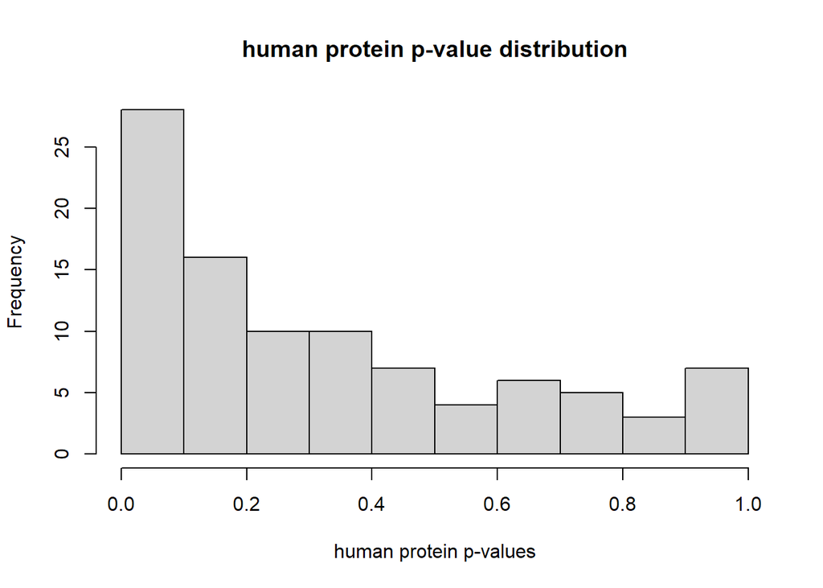

```r
hist(m.mu[,6],xlab="human protein p-values",main="human protein p-value distribution")
```

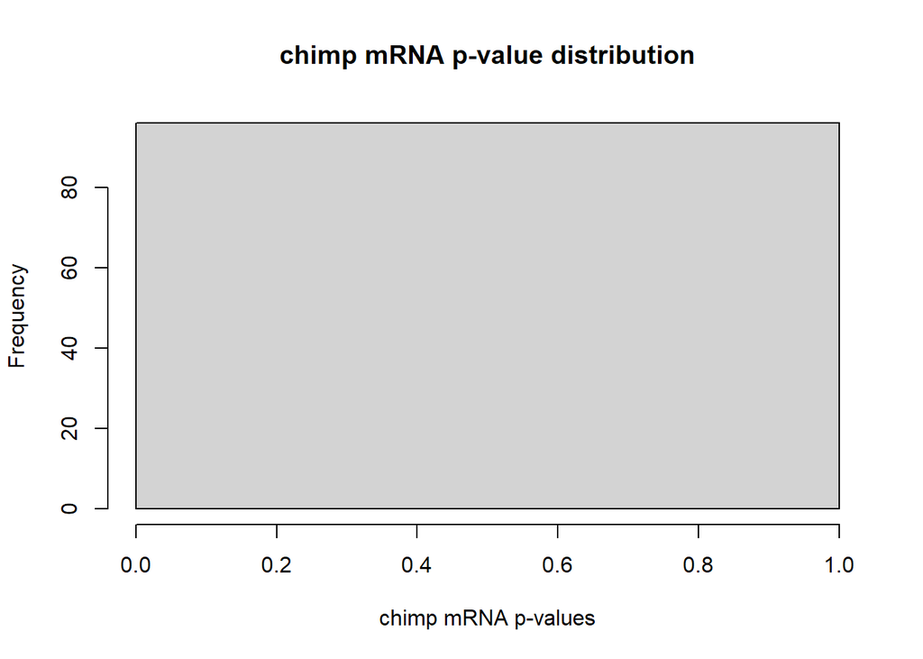

```r
hist(m.mu[,9],xlab="chimp mRNA p-values",main="chimp mRNA p-value distribution")
```

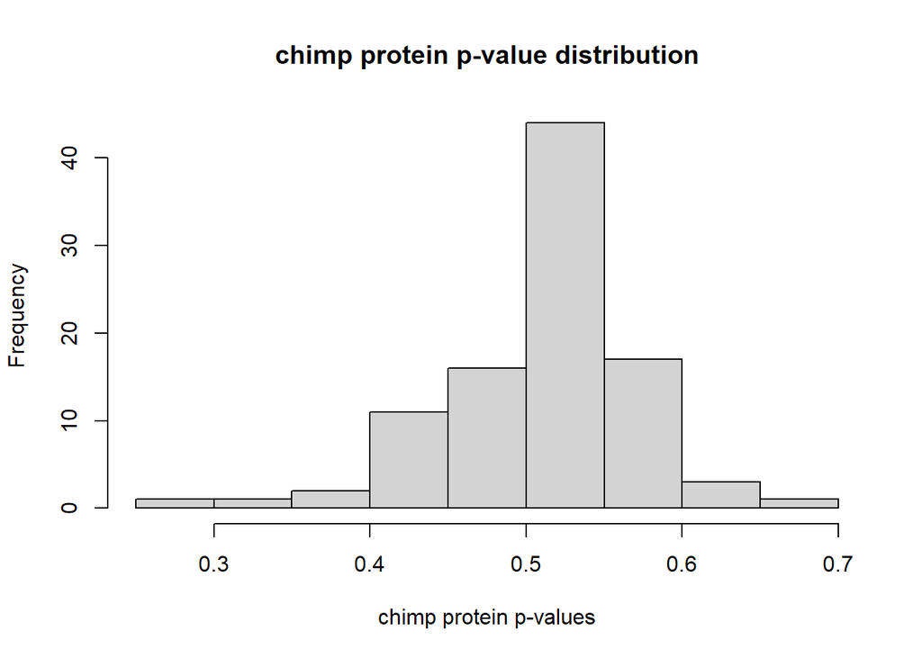

```r
hist(m.mu[,12],xlab="chimp protein p-values",main="chimp protein p-value distribution")
```

## Question 12a

This code looks for an effect of having an isoform of a fusion protein on the expression of a particular gene. I chose gene 1000_at for this experiment. A stripchart indicates that there may be no relationship between these two variables,and ANOVA was non-significant, indicating that there is likely no effect of having a fusion protein isoform on the expression of gene 1000_at. I confirmed the sum of squares between value reported by ANOVA using the linear model coefficients by hand as shown below.

```r
library(ALL);data(ALL)
```

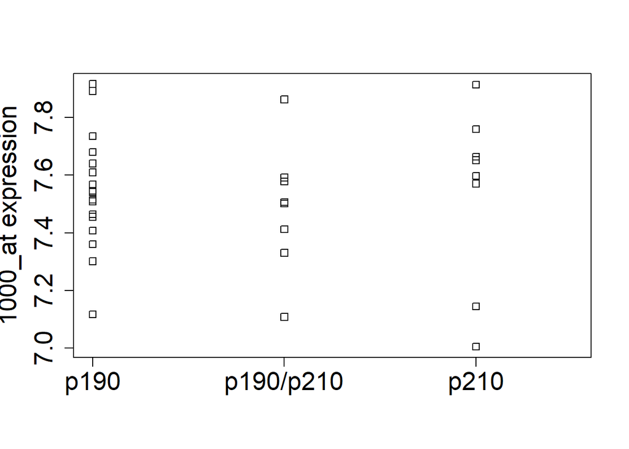

```r
fp.df <- data.frame(fp=pData(ALL)[,"fusion protein"],
                    g=exprs(ALL)["1000_at",])
fp.lm<-lm(g~fp,fp.df)
stripchart(fp.df$g~fp.df$fp,vertical=T,
           ylab="1000_at expression",method='stack',cex.lab=1.7,cex.axis=1.7)
```

```r
coef(lm(g~fp,fp.df))#intercept=mean of first group(190),other two results are subtracted from mean of group190 to get means for 190/210 and 210.
```

```
##  (Intercept)  fpp190/p210       fpp210
##  7.544403178 -0.058276501 -0.006233845
```

```r
mean(fp.df$g[!is.na(fp.df$fp)])#mean overall gene expression(Y variable) for the entire population in dataframe
```

```
## [1] 7.528764
```

```r
mean(fp.df$g[!is.na(fp.df$fp)&fp.df$fp=="p190"])#confirms coefficients
```

```
## [1] 7.544403
```

```r
mean(fp.df$g[!is.na(fp.df$fp)&fp.df$fp=="p190/p210"])
```

```
## [1] 7.486127
```

```r
mean(fp.df$g[!is.na(fp.df$fp)&fp.df$fp=="p210"])
```

```
## [1] 7.538169
```

```r
# SSbetween(#patients*(total mean-group mean) summed for all 3 groups)
17*(7.528764-7.544403178)^2+ 8*(7.528764-7.544403178-(-0.058276501))^2+ 8*(7.528764-7.544403178-(-0.006233845))^2
```

```
## [1] 0.01940914
```

```r
anova(fp.lm)
```

```
## Analysis of Variance Table
##
## Response: g
##           Df  Sum Sq  Mean Sq F value Pr(>F)
## fp         2 0.01941 0.009705   0.178 0.8379
## Residuals 30 1.63595 0.054532
```

## Question 12b

This is a very basic example showing that ANOVA performed on categorical variable with a continuous variable is comparable to a t-test with equal variances performed on the same data set(because ANOVA assumes equal variances as well.

```r
#set up categorical variable x as male and female and y as continuous variable. Calculate ANOVA from linear model and t-test.
x=c("m","m","m","m","m","f","f","f","f","m")
y=rnorm(10)
z=lm(y~x)
anova(z)
```

```
## Analysis of Variance Table
##
## Response: y
##           Df  Sum Sq Mean Sq F value Pr(>F)
## x          1  0.1545 0.15448  0.0968 0.7636
## Residuals  8 12.7609 1.59511
```

```r
t.test(y~x,var.equal=T)
```

```
##
##  Two Sample t-test
##
## data:  y by x
## t = -0.3112, df = 8, p-value = 0.7636
## alternative hypothesis: true difference in means between group f and group m is not equal to 0
## 95 percent confidence interval:
##  -2.133674  1.626260
## sample estimates:
## mean in group f mean in group m
##      -0.9630169      -0.7093098
```